# S03: signatures with stricter sets

Supplement to Figure 1. Panels a and b repeat the training and acute signature ranks with the smaller Π < 0.05 sets. Π is p raised to the power |logFC| (Xiao et al. 2014). Panel c follows each arm’s p < 0.05 training sets through T1, T2 and T3 in both arms, which adds the bout step that a single-window ranking cannot show. The figure reads saved outputs only.

fry is limma’s rotation gene set test: it asks whether a set’s proteins move together in one contrast, and here gives the share moving the same way and an FDR.

## Packages

`analysis_reporting_helpers.R` supplies `write_workbook()`; `figure_style.R` the theme, tags and colours; `figure_panels.R` `signature_barcode()` and `save_figure()`.

```r
library(here)
library(dplyr)
library(tidyr)
library(purrr)
library(tibble)
library(ggplot2)
library(patchwork)
source(here("00_Setup", "Shared_functions", "analysis_reporting_helpers.R"))
source(here("00_Setup", "Shared_functions", "figure_style.R"))
source(here("00_Setup", "Shared_functions", "figure_panels.R"))
```

The protein contrast workbook from `02_Protein_Contrasts` and the set tests from `03_Set_Contrasts`. The chunk creates the output folders, stops if an input is missing, and reads the per-protein results and the fry rows.

```r
stage <- here("05_Figures", "HRvLR", "S03_Signatures")
figure_dir <- file.path(stage, "b_reports")
out <- file.path(stage, "c_data")
walk(c(figure_dir, out), dir.create, recursive = TRUE, showWarnings = FALSE)

inputs <- c(
  contrasts = "03_Group_comparisons/HRvLR/02_Protein_Contrasts/c_data/protein_contrasts.xlsx",
  set_tests = "03_Group_comparisons/HRvLR/03_Set_Contrasts/c_data/set_tests.rds"
)
paths <- map_chr(inputs, here)
if (!all(file.exists(paths))) {
  stop("Missing inputs: ", paste(inputs[!file.exists(paths)], collapse = ", "))
}
read_sheet <- \(sheet) readxl::read_excel(paths[["contrasts"]], sheet)
proteins <- readRDS(paths[["set_tests"]])$protein_results
fry_rows <- read_sheet("fry_concordance")
```

## Panels a and b

`signature_barcode()` places each arm’s Π < 0.05 sets for one window in the other arm’s ranking for the same window, drawn as limma’s barcode (Wu & Smyth 2012). It returns the plot and the numbers it labels.

```r
barcodes <- map(
  set_names(c("Training", "Acute")),
  \(window) signature_barcode(proteins, fry_rows, window, set_level = "pi")
)
```

## Panel c

Panel c is the mean change from each person’s T1 (`02_Protein_Contrasts`, `set_trajectory`). In the arm that chose a set, the training window is where it was selected, so it carries no test, and the bout window shares T2 with the selection: a protein high at T2 by chance reads as up, then down. Those cells are faded and the bout result marked with a dagger. Each window reports the share of proteins moving as they did in training and fry’s FDR on that window’s contrast.

`trajectory` holds the plotted means; `window_stats` the fry result per cell and window; `window_labels` the text drawn in each window.

```r
trajectory <- read_sheet("set_trajectory") |>
  filter(startsWith(set, "nominal_")) |>
  mutate(
    chosen = sub(".*_", "", set_from), direction = sub(".*_", "", set), own = chosen == arm
  )
window_stats <- fry_rows |>
  filter(startsWith(set_from, "Training"), startsWith(set, "nominal_")) |>
  transmute(
    chosen = sub(".*_", "", set_from), arm = sub(".*_", "", ranked_on),
    window = sub("_.*", "", ranked_on), direction = sub(".*_", "", set),
    n_proteins, same_sign_share, fdr,
    label = sprintf("%.0f%% same way\nFDR %.2g", 100 * same_sign_share, fdr)
  )
selection_windows <- distinct(trajectory, chosen, arm, direction) |>
  filter(chosen == arm) |>
  mutate(window = "Training", label = "selection\nwindow")
window_labels <- bind_rows(window_stats, selection_windows) |>
  mutate(
    label = if_else(window == "Acute" & chosen == arm, paste0(label, " \u2020"), label),
    x = if_else(window == "Training", 1.5, 2.5),
    y = if_else(direction == "up", Inf, -Inf), vjust = if_else(direction == "up", 1.4, -0.5)
  )
```

Rows are the arm that chose the sets, columns the arm they are measured in. The training window is shaded in the training tint and the bout window in the acute tint.

```r
cell_names <- c(
  chosen_HR = "Changed by training in HR", chosen_LR = "Changed by training in LR",
  in_HR = "Measured in HR", in_LR = "Measured in LR"
)
as_cells <- \(d) mutate(d, chosen = paste0("chosen_", chosen), arm = paste0("in_", arm))
shade_window <- \(from, to, family) {
  annotate(
    "rect",
    xmin = from, xmax = to, ymin = -Inf, ymax = Inf,
    fill = contrast_tone("fill")[[family]], alpha = 0.6
  )
}
panel_trajectory <- ggplot(
  as_cells(trajectory), aes(timepoint, mean_change, group = direction, colour = direction)
) +
  shade_window(1, 2, "Training") +
  shade_window(2, 3, "Acute") +
  geom_hline(yintercept = 0, linewidth = 0.25) +
  geom_errorbar(
    aes(ymin = mean_change - se, ymax = mean_change + se, alpha = own),
    width = 0.06, linewidth = 0.3
  ) +
  geom_line(aes(alpha = own), linewidth = 0.6) +
  geom_point(aes(alpha = own), size = 1.3) +
  geom_text(
    aes(x, y, label = label, vjust = vjust, colour = direction), as_cells(window_labels),
    inherit.aes = FALSE, size = 1.8, lineheight = 0.9
  ) +
  scale_alpha_manual(values = c(`TRUE` = 0.35, `FALSE` = 1), guide = "none") +
  scale_colour_manual(
    values = c(up = direction_colours[["Up"]], down = direction_colours[["Down"]]),
    labels = c(down = "decreased in training", up = "increased in training"), name = NULL
  ) +
  scale_x_discrete(expand = expansion(add = 0.04)) +
  scale_y_continuous(expand = expansion(mult = 0.45)) +
  ggh4x::facet_grid2(
    chosen ~ arm,
    scales = "free_y", independent = "y", switch = "y",
    labeller = as_labeller(cell_names)
  ) +
  labs(
    x = NULL, y = NULL, title = "Where training-responsive proteins go after the bout",
    subtitle = paste(
      "p < 0.05 sets; change from own T1 (log2) \u00b1 SE; % same way, fry FDR;",
      "\u2020 T2 shared"
    )
  ) +
  figure_theme +
  theme(
    legend.position = "bottom", strip.placement = "outside",
    strip.text = element_text(size = 6), panel.spacing = unit(2, "mm")
  )
```

## Validation

Every plotted number traces to its source table before anything is written: eight barcode labels, 4 cells by 2 directions by 3 time points of trajectory, and 12 window results (the other arm’s training window, plus both arms’ bout windows, per set). Each cell and direction gets two labels.

```r
pi_numbers <- map(barcodes, "labels") |> list_rbind()
stopifnot(
  nrow(pi_numbers) == 8,
  nrow(trajectory) == 4 * 2 * 3,
  # Other arm's training window, plus both arms' bout windows, per set.
  nrow(window_stats) == 12,
  all(count(window_labels, chosen, arm, direction)$n == 2)
)
```

## Figure

The three panels side by side, saved to `b_reports/s03_signatures.pdf` at 300 by 110 mm.

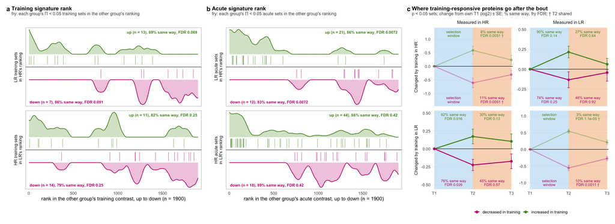

Figure 1: Signature ranks at Π < 0.05 (a, b) and training sets followed through the bout (c).

```r
figure <- wrap_plots(
  barcodes$Training$plot, barcodes$Acute$plot, panel_trajectory,
  nrow = 1
) +
  plot_annotation(tag_levels = "a") &
  figure_tags
save_figure(figure, figure_dir, "s03_signatures", width = 300, height = 110)
print(figure)
```

## Save

`c_data/s03_signatures.xlsx` holds every number the panels draw.

```r
sheets <- list(
  pi_barcode = select(pi_numbers, window, chosen, ranked_in, direction, n, same_sign_share, fdr),
  trajectory = select(trajectory, set_from, set, n_proteins, arm, timepoint, mean_change, se),
  window_stats = select(
    window_stats, chosen, arm, window, direction, n_proteins, same_sign_share, fdr
  )
)
holds <- c(
  "Panels a, b: each arm's Pi < 0.05 sets in the other arm's ranking: n, % same way, fry FDR.",
  "Panel c: mean change from each subject's T1 (and SE) per training set, arm and time point.",
  "Panel c: per cell and window, share of proteins moving as in training and fry FDR."
)
write_workbook(sheets, holds, file.path(out, "s03_signatures.xlsx"), inputs, paths)
```